# Study 2

Lily Wu, z5164942

The aim of study 2 is to establish whether getting people to think about the accuracy of news headlines influences how likely they are to share true and false COVID-19 news on social media.

There are two groups - nudge group (judged accuracy of non-COVID-19 headlines at the beginning of study by answering ‘yes’ or ‘no’) - control group (did not rate accuracy of non-COVID-19 headlines)

The measured variable is the likelihood of sharing true or false COVID-19 news (1-6 Likert scale, 1 = extremely unlikely to share, 6 = highly likely to share).

### Install and load tidyverse package

```r
install.packages("tidyverse") # Install tidyverse
library(tidyverse) # Load tidyverse
```

### Load the data

```r
# Load data into new variable
study2 <- readxl::read_xlsx("NudgeDataStudy2.xlsx")
```

```
## * `` -> ...31
```

```r
# Print data
print(study2)
```

```
## # A tibble: 222 x 47
##    Group  Fake  Real Discern CRT_ACC SciKnow   MMS ResponseID Finished rid
##    <dbl> <dbl> <dbl>   <dbl>   <dbl>   <dbl> <dbl> <chr>         <dbl> <chr>
##  1     1  4.93  4.73 -0.2      0       0.529   5.2 R_1isxtrw…        1 5e6c…
##  2     1  5.4   5.67  0.267    0       0.294   3.3 R_2tzBU81…        1 5e6d…
##  3     2  3.8   4.07  0.267    0       0.235   4.6 R_3JfvU36…        1 5e6c…
##  4     1  5.93  5.87 -0.0667   0       0.529   6.2 R_VJgdtWU…        1 5e6d…
##  5     1  2.93  2.13 -0.8      0.667   0.882   4.1 R_wSLqU87…        1 5e6d…
##  6     1  5.73  5.6  -0.133    0.833   0.882   6.1 R_2alR23X…        1 5e6d…
##  7     2  5.87  5.8  -0.0667   0       0.294   5.2 R_3jUvbU7…        1 5e6e…
##  8     2  1.67  1.8   0.133    0.5     0.647   4.2 R_3rDmInq…        1 5e6c…
##  9     1  1.27  1.07 -0.2      0.667   0.588   2.7 R_2X7puGf…        1 5e6c…
## 10     1  3.8   3.27 -0.533    0.167   0.471   3.2 R_2xLRpSn…        1 5e6d…
## # … with 212 more rows, and 37 more variables: age <dbl>, gender <dbl>,
## #   COVID_concern_1 <chr>, COVID_news <dbl>, Fake1_1 <dbl>, Fake1_2 <dbl>,
## #   Fake1_3 <dbl>, Fake1_4 <dbl>, Fake1_5 <dbl>, Fake1_6 <dbl>, Fake1_7 <dbl>,
## #   Fake1_8 <dbl>, Fake1_9 <dbl>, Fake1_10 <dbl>, Fake1_11 <dbl>,
## #   Fake1_12 <dbl>, Fake1_13 <dbl>, Fake1_14 <dbl>, Fake1_15 <dbl>, `Fake
## #   Average Sharing Tendency` <dbl>, ...31 <dbl>, Real1_1 <dbl>, Real1_2 <dbl>,
## #   Real1_3 <dbl>, Real1_4 <dbl>, Real1_5 <dbl>, Real1_6 <dbl>, Real1_7 <dbl>,
## #   Real1_8 <dbl>, Real1_9 <dbl>, Real1_10 <dbl>, Real1_11 <dbl>,
## #   Real1_12 <dbl>, Real1_13 <dbl>, Real1_14 <dbl>, Real1_15 <dbl>, `Real
## #   Average Sharing Tendency` <dbl>
```

## Data wrangling for scatterplots

Similarly to Study 1, I selected the relevant columns, renamed columns and computed new variables to make the dataset easier to use for graphing.

### Selecting relevant columns

```r
# Select relevant columns
study2 <- study2 %>%
  select(Group, Fake1_1, Fake1_2, Fake1_3, Fake1_4, Fake1_5, Fake1_6, Fake1_7, Fake1_8, Fake1_9, Fake1_10, Fake1_11, Fake1_12, Fake1_13, Fake1_14, Fake1_15, Real1_1, Real1_2, Real1_3, Real1_4, Real1_5, Real1_6, Real1_7, Real1_8, Real1_9, Real1_10, Real1_11, Real1_12, Real1_13, Real1_14, Real1_15)
# Print data
glimpse(study2)
```

```
## Rows: 222
## Columns: 31
## $ Group    <dbl> 1, 1, 2, 1, 1, 1, 2, 2, 1, 1, 1, 1, 2, 1, 2, 1, 1, 2, 2, 2, …
## $ Fake1_1  <dbl> 5, 6, 1, 6, 1, 6, 6, 1, 1, 2, 5, 6, 2, 2, 1, 1, 6, 1, 2, 1, …
## $ Fake1_2  <dbl> 5, 5, 4, 6, 1, 6, 5, 1, 1, 4, 3, 4, 2, 1, 1, 1, 1, 1, 1, 1, …
## $ Fake1_3  <dbl> 5, 6, 4, 5, 5, 6, 6, 1, 1, 1, 3, 1, 2, 1, 1, 1, 6, 6, 1, 1, …
## $ Fake1_4  <dbl> 4, 5, 4, 6, 4, 6, 6, 1, 1, 6, 4, 1, 2, 1, 4, 1, 6, 3, 1, 1, …
## $ Fake1_5  <dbl> 5, 5, 3, 6, 6, 6, 6, 1, 1, 1, 6, 1, 2, 1, 1, 1, 1, 2, 1, 1, …
## $ Fake1_6  <dbl> 5, 6, 5, 6, 5, 6, 5, 3, 5, 4, 6, 1, 2, 4, 1, 1, 6, 1, 1, 1, …
## $ Fake1_7  <dbl> 5, 5, 3, 6, 1, 6, 6, 3, 1, 5, 4, 6, 2, 4, 1, 1, 6, 1, 1, 1, …
## $ Fake1_8  <dbl> 5, 5, 4, 6, 3, 5, 6, 1, 1, 4, 5, 6, 2, 1, 1, 1, 6, 1, 2, 1, …
## $ Fake1_9  <dbl> 4, 6, 4, 6, 1, 6, 6, 3, 1, 4, 5, 6, 2, 3, 3, 1, 6, 1, 1, 1, …
## $ Fake1_10 <dbl> 5, 5, 4, 6, 6, 5, 6, 2, 1, 1, 3, 6, 1, 5, 1, 3, 6, 1, 1, 1, …
## $ Fake1_11 <dbl> 5, 6, 5, 6, 2, 5, 6, 4, 1, 6, 5, 1, 3, 2, 1, 3, 6, 1, 4, 2, …
## $ Fake1_12 <dbl> 5, 5, 4, 6, 3, 6, 6, 1, 1, 6, 1, 6, 2, 4, 1, 1, 6, 1, 1, 1, …
```

[output cut: 18 more lines]

### Renaming columns

```r
# Rename columns
study2 <- study2 %>%
  rename(FakeQ1 = Fake1_1, FakeQ2 = Fake1_2, FakeQ3 = Fake1_3, FakeQ4 = Fake1_4, FakeQ5 = Fake1_5, FakeQ6 = Fake1_6, FakeQ7 = Fake1_7, FakeQ8 = Fake1_8, FakeQ9 = Fake1_9, FakeQ10 = Fake1_10, FakeQ11 = Fake1_11, FakeQ12 = Fake1_12, FakeQ13 = Fake1_13, FakeQ14 = Fake1_14, FakeQ15 = Fake1_15, RealQ1 = Real1_1, RealQ2 = Real1_2, RealQ3 = Real1_3, RealQ4 = Real1_4, RealQ5 = Real1_5, RealQ6 = Real1_6, RealQ7 = Real1_7, RealQ8 = Real1_8, RealQ9 = Real1_9, RealQ10 = Real1_10, RealQ11 = Real1_11, RealQ12 = Real1_12, RealQ13 = Real1_13, RealQ14 = Real1_14, RealQ15 = Real1_15)
# Print data
glimpse(study2)
```

```
## Rows: 222
## Columns: 31
## $ Group   <dbl> 1, 1, 2, 1, 1, 1, 2, 2, 1, 1, 1, 1, 2, 1, 2, 1, 1, 2, 2, 2, 1…
## $ FakeQ1  <dbl> 5, 6, 1, 6, 1, 6, 6, 1, 1, 2, 5, 6, 2, 2, 1, 1, 6, 1, 2, 1, 1…
## $ FakeQ2  <dbl> 5, 5, 4, 6, 1, 6, 5, 1, 1, 4, 3, 4, 2, 1, 1, 1, 1, 1, 1, 1, 4…
## $ FakeQ3  <dbl> 5, 6, 4, 5, 5, 6, 6, 1, 1, 1, 3, 1, 2, 1, 1, 1, 6, 6, 1, 1, 5…
## $ FakeQ4  <dbl> 4, 5, 4, 6, 4, 6, 6, 1, 1, 6, 4, 1, 2, 1, 4, 1, 6, 3, 1, 1, 6…
## $ FakeQ5  <dbl> 5, 5, 3, 6, 6, 6, 6, 1, 1, 1, 6, 1, 2, 1, 1, 1, 1, 2, 1, 1, 4…
## $ FakeQ6  <dbl> 5, 6, 5, 6, 5, 6, 5, 3, 5, 4, 6, 1, 2, 4, 1, 1, 6, 1, 1, 1, 1…
## $ FakeQ7  <dbl> 5, 5, 3, 6, 1, 6, 6, 3, 1, 5, 4, 6, 2, 4, 1, 1, 6, 1, 1, 1, 1…
## $ FakeQ8  <dbl> 5, 5, 4, 6, 3, 5, 6, 1, 1, 4, 5, 6, 2, 1, 1, 1, 6, 1, 2, 1, 5…
## $ FakeQ9  <dbl> 4, 6, 4, 6, 1, 6, 6, 3, 1, 4, 5, 6, 2, 3, 3, 1, 6, 1, 1, 1, 1…
## $ FakeQ10 <dbl> 5, 5, 4, 6, 6, 5, 6, 2, 1, 1, 3, 6, 1, 5, 1, 3, 6, 1, 1, 1, 3…
## $ FakeQ11 <dbl> 5, 6, 5, 6, 2, 5, 6, 4, 1, 6, 5, 1, 3, 2, 1, 3, 6, 1, 4, 2, 6…
## $ FakeQ12 <dbl> 5, 5, 4, 6, 3, 6, 6, 1, 1, 6, 1, 6, 2, 4, 1, 1, 6, 1, 1, 1, 1…
```

[output cut: 18 more lines]

### Computing new columns

I calculated the total and average sharing tendency per participant for real and fake headlines across both groups.

```r
# Creating new columns using the nudge group data
s2nudge <- study2 %>%
 filter(Group == 2) %>% # Filter for nudge group only
 rowwise() %>% # Ask R to see data in rows
 mutate(FH_N_Total_Sharing_Tendency = sum(FakeQ1, FakeQ2, FakeQ3, FakeQ4, FakeQ5, FakeQ6, FakeQ7, FakeQ8, FakeQ9, FakeQ10, FakeQ11, FakeQ12, FakeQ13, FakeQ14, FakeQ15)) %>% # Create new column to calculate total sharing tendency for fake headlines
  mutate(RH_N_Total_Sharing_Tendency = sum(RealQ1, RealQ2, RealQ3, RealQ4, RealQ5, RealQ6, RealQ7, RealQ8, RealQ9, RealQ10, RealQ11, RealQ12, RealQ13, RealQ14, RealQ15)) %>% # Create new column to calculate total sharing tendency for real headlines
  mutate(FH_N_Average_Sharing_Tendency = FH_N_Total_Sharing_Tendency/15) %>% # Create new column to calculate average sharing tendency for fake headlines
  mutate(RH_N_Average_Sharing_Tendency = RH_N_Total_Sharing_Tendency/15) # Create new column to calculate total sharing tendency for real headlines
glimpse(s2nudge) # Print data
```

```
## Rows: 108
## Columns: 35
## $ Group                         <dbl> 2, 2, 2, 2, 2, 2, 2, 2, 2, 2, 2, 2, 2, …
## $ FakeQ1                        <dbl> 1, 6, 1, 2, 1, 1, 2, 1, 3, 3, 4, 3, 1, …
## $ FakeQ2                        <dbl> 4, 5, 1, 2, 1, 1, 1, 1, 4, 1, 4, 3, 6, …
## $ FakeQ3                        <dbl> 4, 6, 1, 2, 1, 6, 1, 1, 4, 4, 3, 6, 2, …
## $ FakeQ4                        <dbl> 4, 6, 1, 2, 4, 3, 1, 1, 4, 3, 4, 4, 1, …
## $ FakeQ5                        <dbl> 3, 6, 1, 2, 1, 2, 1, 1, 2, 3, 3, 1, 1, …
## $ FakeQ6                        <dbl> 5, 5, 3, 2, 1, 1, 1, 1, 2, 4, 3, 2, 1, …
## $ FakeQ7                        <dbl> 3, 6, 3, 2, 1, 1, 1, 1, 2, 4, 3, 4, 2, …
## $ FakeQ8                        <dbl> 4, 6, 1, 2, 1, 1, 2, 1, 4, 4, 4, 3, 6, …
## $ FakeQ9                        <dbl> 4, 6, 3, 2, 3, 1, 1, 1, 5, 4, 4, 2, 1, …
## $ FakeQ10                       <dbl> 4, 6, 2, 1, 1, 1, 1, 1, 4, 4, 4, 6, 6, …
## $ FakeQ11                       <dbl> 5, 6, 4, 3, 1, 1, 4, 2, 4, 4, 4, 5, 6, …
## $ FakeQ12                       <dbl> 4, 6, 1, 2, 1, 1, 1, 1, 5, 3, 4, 3, 1, …
```

[output cut: 22 more lines]

```r
# Creating new columns using the control group data
s2control <- study2 %>%
  filter(Group == 1) %>% # Filter for control group only
 rowwise() %>% # Ask R to see data in rows
 mutate(FH_C_Total_Sharing_Tendency = sum(FakeQ1, FakeQ2, FakeQ3, FakeQ4, FakeQ5, FakeQ6, FakeQ7, FakeQ8, FakeQ9, FakeQ10, FakeQ11, FakeQ12, FakeQ13, FakeQ14, FakeQ15)) %>% # Create new column to calculate total sharing tendency for fake headlines
  mutate(RH_C_Total_Sharing_Tendency = sum(RealQ1, RealQ2, RealQ3, RealQ4, RealQ5, RealQ6, RealQ7, RealQ8, RealQ9, RealQ10, RealQ11, RealQ12, RealQ13, RealQ14, RealQ15)) %>% # Create new column to calculate total sharing tendency for real headlines
  mutate(FH_C_Average_Sharing_Tendency = FH_C_Total_Sharing_Tendency/15) %>% # Create new column to calculate average sharing tendency for fake headlines
  mutate(RH_C_Average_Sharing_Tendency = RH_C_Total_Sharing_Tendency/15) # Create new column to calculate total sharing tendency for real headlines
glimpse(s2control) # Print data
```

```
## Rows: 114
## Columns: 35
## $ Group                         <dbl> 1, 1, 1, 1, 1, 1, 1, 1, 1, 1, 1, 1, 1, …
## $ FakeQ1                        <dbl> 5, 6, 6, 1, 6, 1, 2, 5, 6, 2, 1, 6, 1, …
## $ FakeQ2                        <dbl> 5, 5, 6, 1, 6, 1, 4, 3, 4, 1, 1, 1, 4, …
## $ FakeQ3                        <dbl> 5, 6, 5, 5, 6, 1, 1, 3, 1, 1, 1, 6, 5, …
## $ FakeQ4                        <dbl> 4, 5, 6, 4, 6, 1, 6, 4, 1, 1, 1, 6, 6, …
## $ FakeQ5                        <dbl> 5, 5, 6, 6, 6, 1, 1, 6, 1, 1, 1, 1, 4, …
## $ FakeQ6                        <dbl> 5, 6, 6, 5, 6, 5, 4, 6, 1, 4, 1, 6, 1, …
## $ FakeQ7                        <dbl> 5, 5, 6, 1, 6, 1, 5, 4, 6, 4, 1, 6, 1, …
## $ FakeQ8                        <dbl> 5, 5, 6, 3, 5, 1, 4, 5, 6, 1, 1, 6, 5, …
## $ FakeQ9                        <dbl> 4, 6, 6, 1, 6, 1, 4, 5, 6, 3, 1, 6, 1, …
## $ FakeQ10                       <dbl> 5, 5, 6, 6, 5, 1, 1, 3, 6, 5, 3, 6, 3, …
## $ FakeQ11                       <dbl> 5, 6, 6, 2, 5, 1, 6, 5, 1, 2, 3, 6, 6, …
## $ FakeQ12                       <dbl> 5, 5, 6, 3, 6, 1, 6, 1, 6, 4, 1, 6, 1, …
```

[output cut: 22 more lines]

The purpose of creating these new columns is to figure out the willingness to share either real or fake headlines in both the nudge and control groups. Average sharing tendencies for real and fake headlines are compared between groups to determine the effect of the nudge.

## Graphing the data

Violin plots can be used to compare the nudge and control groups on their average sharing rates for real and fake COVID-19 headlines. Adding box plots to the violin plots is a way to show the median and quartile range for the data. I also visualised the mean of each condition which is represented by the dot.

### Fake Headlines

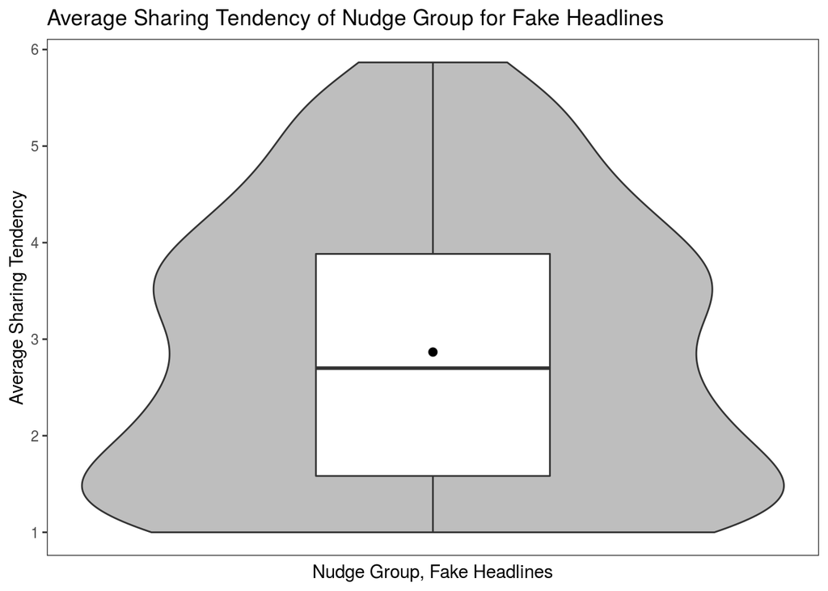

```r
# Fake Headlines, Nudge Group
s2nudgeFH <- ggplot(data = s2nudge) +
  geom_violin(aes(x = Group, y = FH_N_Average_Sharing_Tendency), fill = "grey") + # Create violin plot for nudge group and their average responses to fake headlines
  geom_boxplot(aes(x = Group, y = FH_N_Average_Sharing_Tendency), width = 0.3) + # Create box plot
  stat_summary(aes(x = Group, y = FH_N_Average_Sharing_Tendency), fun = mean, geom = "point", size=2) + # Add mean point
  scale_y_continuous(breaks=c(1,2,3,4,5,6)) + # Specify y-axis points
  xlab("Nudge Group, Fake Headlines") + # Change x-axis label
  ylab("Average Sharing Tendency") + # Change y-axis label
  ggtitle("Average Sharing Tendency of Nudge Group for Fake Headlines") + # Change plot title
  theme_bw() + # Change theme
  theme(axis.ticks.x = element_blank(), # Remove x-axis ticks
        panel.grid.major = element_blank(), # Remove gridlines
        panel.grid.minor = element_blank(), # Remove gridlines
        panel.background = element_blank(), # Remove background colour
        axis.text.x = element_blank()) # Remove x-axis values
print(s2nudgeFH) # Print graph
```

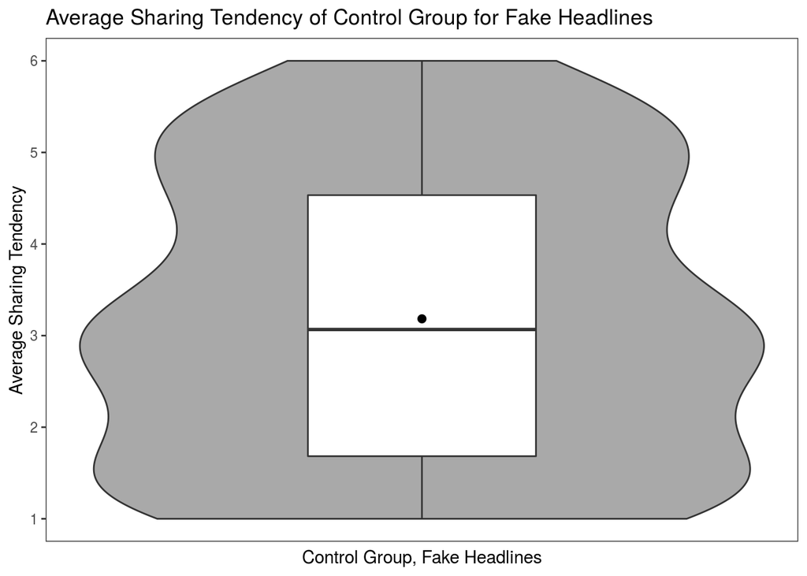

```r
# Fake Headlines, Control Group
s2controlFH <- ggplot(data = s2control) +
  geom_violin(aes(x = Group, y = FH_C_Average_Sharing_Tendency), fill = "darkgrey") + # Create violin plot for nudge group and their average responses to true headlines
  geom_boxplot(aes(x = Group, y = FH_C_Average_Sharing_Tendency), width = 0.3) + # Create box plot
    stat_summary(aes(x = Group, y = FH_C_Average_Sharing_Tendency), fun = mean, geom = "point", size=2) + # Add mean point
    scale_y_continuous(breaks=c(1,2,3,4,5,6)) + # Specify y-axis points
  xlab("Control Group, Fake Headlines") + # Change x-axis label
  ylab("Average Sharing Tendency") + # Change y-axis label
  ggtitle("Average Sharing Tendency of Control Group for Fake Headlines") + # Change plot title
  theme_bw() + # Change theme
  theme(axis.ticks.x = element_blank(), # Remove x-axis ticks
        panel.grid.major = element_blank(), # Remove gridlines
        panel.grid.minor = element_blank(), # Remove gridlines
        panel.background = element_blank(), # Remove background colour
        axis.text.x = element_blank()) # Remove x-axis values
print(s2controlFH) # Print graph
```

To visually gauge the effect of the nudge on sharing tendencies, we can compare both groups on how they responded to fake headlines using the violin plots. The mean average sharing tendency for the nudge group (slightly below 3) is slightly lower than the mean for the control group (slightly above 3). This could be a significant difference, but we cannot claim the nudge helped in reducing the sharing of fake headlines without statistical analysis. From the graphs, there seem to be less participants choosing 5 or 6 (meaning likely or highly likely to share) for the nudge group than the control.

### Real Headlines

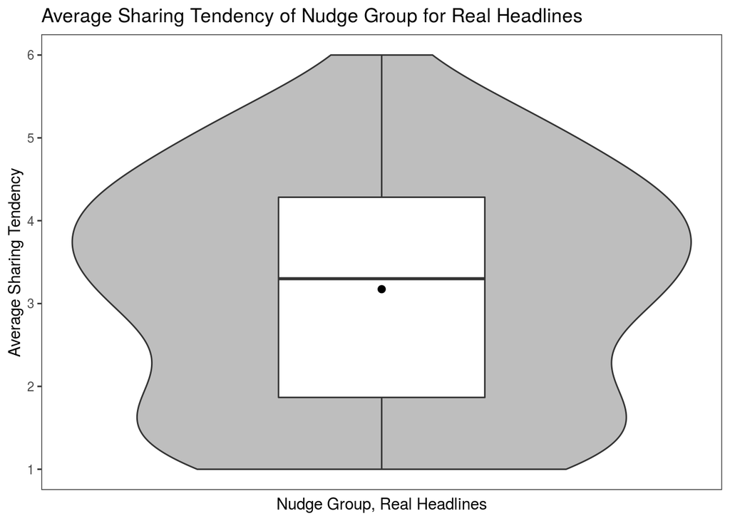

```r
# Real Headlines, Nudge Group
s2nudgeRH <- ggplot(data = s2nudge) +
  geom_violin(aes(x = Group, y = RH_N_Average_Sharing_Tendency), fill = "grey") + # Create violin plot for control group and their average responses to fake headlines
  geom_boxplot(aes(x = Group, y = RH_N_Average_Sharing_Tendency), width = 0.3) + # Create box plot
    stat_summary(aes(x = Group, y = RH_N_Average_Sharing_Tendency), fun = mean, geom = "point", size=2) + # Add mean point
  scale_y_continuous(breaks=c(1,2,3,4,5,6)) + # Specify y-axis points
  xlab("Nudge Group, Real Headlines") + # Change x-axis label
  ylab("Average Sharing Tendency") + # Change y-axis label
  ggtitle("Average Sharing Tendency of Nudge Group for Real Headlines") + # Change plot title
  theme_bw() + # Change theme
  theme(axis.ticks.x = element_blank(), # Remove x-axis ticks
        panel.grid.major = element_blank(), # Remove gridlines
        panel.grid.minor = element_blank(), # Remove gridlines
        panel.background = element_blank(), # Remove background colour
        axis.text.x = element_blank()) # Remove x-axis values
print(s2nudgeRH) # Print graph
```

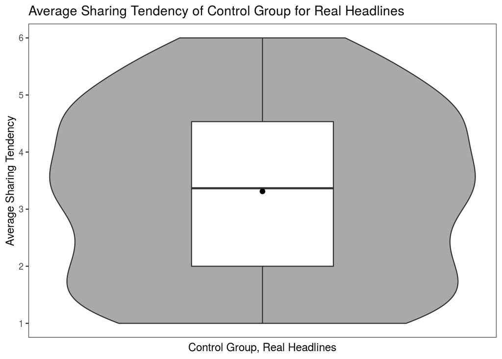

```r
# Real Headlines, Control Group
s2controlRH <- ggplot(data = s2control) +
  geom_violin(aes(x = Group, y = RH_C_Average_Sharing_Tendency), fill = "darkgrey") + # Create violin plot for control group and their average responses to true headlines
  geom_boxplot(aes(x = Group, y = RH_C_Average_Sharing_Tendency), width = 0.3) + # Create box plot
    stat_summary(aes(x = Group, y = RH_C_Average_Sharing_Tendency), fun = mean, geom = "point", size=2) + # Add mean point
  scale_y_continuous(breaks=c(1,2,3,4,5,6)) + # Specify y-axis points
  xlab("Control Group, Real Headlines") + # Change x-axis label
  ylab("Average Sharing Tendency") + # Change y-axis label
  ggtitle("Average Sharing Tendency of Control Group for Real Headlines") + # Change plot title
  theme_bw() + # Change theme
  theme(axis.ticks.x = element_blank(), # Remove x-axis ticks
        panel.grid.major = element_blank(), # Remove gridlines
        panel.grid.minor = element_blank(), # Remove gridlines
        panel.background = element_blank(), # Remove background colour
        axis.text.x = element_blank()) # Remove x-axis values
print(s2controlRH) # Print graph
```

The mean for both groups is quite similar (a bit above 3). The general shape of the violin plot is also quite similar for both groups with the widest part of the plot from 3 to 5. We can assume that both groups responded similarly for real headlines.

Comparing across all four graphs, participants seem less likely to share fake headlines than real headlines. Lowest average sharing tendencies were produced when the nudge group received fake headlines. This visualisation hints at the possibility that the nudge may help in reducing the sharing of fake headlines, but this assumption would need to be supported by statistical analysis.